# GSS challange Less Data

# Introduction

Is attitude toward capitol punishment (cappun) independent of race (race)? If not, then whose view differs from whom??

# Methods

```r
mydata <- mydata %>%
mutate(across(where(is.character), as.factor))
```

# Results

## Descriptive Results

### Graphical Descriptive Results

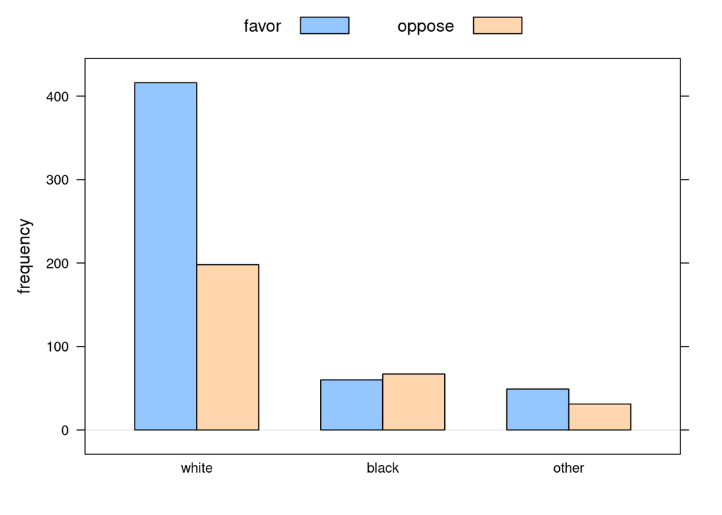

```r
barchartGC(~race + cappun,data=mydata)
```

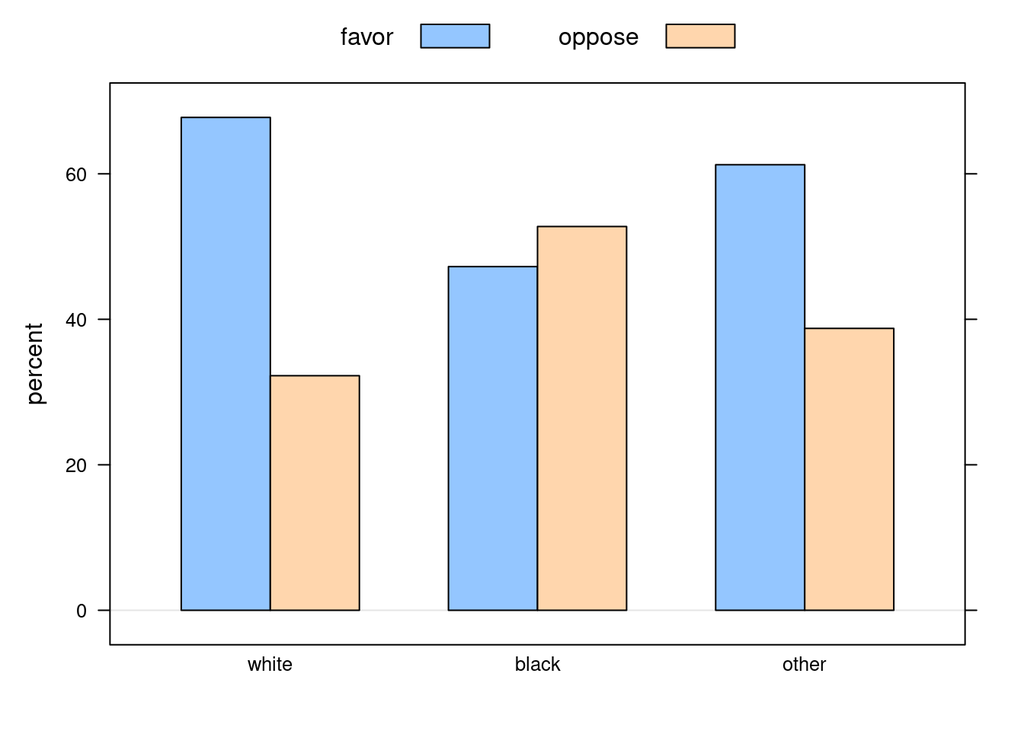

```r
barchartGC(~race + cappun,data=mydata, type="percent")
```

For the data shown above, the population that favors capitol punishment the most is the whites, then the “other” and then the black. The data here is similar to the data from the master branch where the percentages of those in favor and opposing are highly similar.

## Now with LESS data (more variables give less data due to NA’s) create the approate graphic displays to answer the question.

### Numerical Descriptive Results

```r
table1 <- xtabs(~race + cappun, data=mydata)
rowPerc(table1)
```

```
##        cappun
## race     favor oppose  Total
##   white  67.75  32.25 100.00
##   black  47.24  52.76 100.00
##   other  61.25  38.75 100.00
```

```r
print("----------")
```

```
## [1] "----------"
```

```r
colPerc(table1)
```

```
##        cappun
## race     favor oppose
##   white  79.24  66.89
##   black  11.43  22.64
##   other   9.33  10.47
##   Total 100.00 100.00
```

The table above shows that there is 68% of the white population in favor of capitol punishment while 32% is opposed. Other population has 61% in favor and 39% opposed. The black population has 47% in favor with 53% opposed. The percentages here differ from those in the master branch, but are still very similar with each other.

## Inferential Results

```r
chisq.test(table1)
```

```
##
##  Pearson's Chi-squared test
##
## data:  table1
## X-squared = 19.477, df = 2, p-value = 5.896e-05
```

```r
chisqtestGC(table1)
```

```
## Pearson's Chi-squared test
##
## Observed Counts:
##        cappun
## race    favor oppose
##   white   416    198
##   black    60     67
##   other    49     31
##
## Counts Expected by Null:
##        cappun
## race     favor oppose
##   white 392.63 221.37
##   black  81.21  45.79
##   other  51.16  28.84
##
## Contributions to the chi-square statistic:
##        cappun
## race    favor oppose
##   white  1.39   2.47
##   black  5.54   9.83
##   other  0.09   0.16
##
##
## Chi-Square Statistic = 19.4773
## Degrees of Freedom of the table = 2
## P-Value = 1e-04
```

```r
fisher.test(table1)
```

```
##
##  Fisher's Exact Test for Count Data
##
## data:  table1
## p-value = 7.704e-05
## alternative hypothesis: two.sided
```

```r
fisherXY (mydata$race,mydata$cappun, printAll=TRUE)
```

```
##
## contingency table:
##        y
## x       favor oppose
##   white   416    198
##   black    60     67
##   other    49     31
##
## ***All 2X2 tests****
##
## [1] "white" "black"
## [1] "favor"  "oppose"
##        y
## x       favor oppose
##   white   416    198
##   black    60     67
##
##  Fisher's Exact Test for Count Data
##
## data:  fTempTable
## p-value = 1.741e-05
## alternative hypothesis: true odds ratio is not equal to 1
## 95 percent confidence interval:
##  1.562325 3.521989
## sample estimates:
## odds ratio
##   2.343236
##
##
## [1] "white" "other"
## [1] "favor"  "oppose"
##        y
## x       favor oppose
##   white   416    198
##   other    49     31
##
##  Fisher's Exact Test for Count Data
##
## data:  fTempTable
## p-value = 0.2565
```

[output cut: 10 more lines]

```
##        y
## x       favor oppose
##   black    60     67
##   other    49     31
##
##  Fisher's Exact Test for Count Data
##
## data:  fTempTable
## p-value = 0.06299
## alternative hypothesis: true odds ratio is not equal to 1
## 95 percent confidence interval:
##  0.3075892 1.0389651
## sample estimates:
## odds ratio
##  0.5681142
```

The fisher XY test tells us that white and black are different with a p-value of 0.00001741. There is no difference between black and other since the p-value is 0.06299 and with white and other the p-value is 0.2565.

# Discussion and Conclusion

The data above shows that the population of whites had the most in favor for capitol punishment. The second highest was the population of other and the lowest was the population of blacks. This is similar to the values from the master branch, but the percentages in this branch were higher than in the master branch since we were given a smaller sample size.